# Final Project Report

Author

Phoebe Jones

## Abstract

The objective of this project is to build a model capable of predicting times for future boats competing in the Adirondack Canoe Classic (90-Miler). Motivated by Ryan Matthews’ model for AuSable River Marathon times, this project relies on historic results from the 90-Miler as well as corresponding weather and water level data. Using this data, a linear regression model was built to predict completion times for each day of the three-day race. This model became the center of a Shiny App, allowing users to choose values for the model’s predictors and receive a result. This app gives insight into the previously abstract impacts of various factors on competitor’s times.

## Introduction

The Adirondack (ADK) Canoe Classic (often called “The 90-Miler) is a three day paddling race through the Adirondacks. The race is, as the nickname suggests, 90 miles of paddling and portaging (boat carrying over land) completed by various types of crafts paddled by wide ranges of people. The race has been held over 40 times and results containing times as well as paddler and boat class information are available on [PaddleStats](https://paddlestats.net/racehistory/ADK90).

For this project, results from PaddleStats were combined with water level and weather data collected from [USGS](https://www.usgs.gov/) and [Open-Meteo](https://open-meteo.com/) respectively. The water level data for each day was sourced from a measuring station somewhere along that day’s course at 6:30am on the relevant day. Day 1 was sourced from First Lake at Old Forge, NY, Day 2 from the Raquette River at Piercefield, NY, and Day 3 from Saranac River at Plattsburgh, NY. The weather data is the mean temperature in degrees Fahrenheit similarly at a relevant locale for the day. Day 1 and Day 3 have the same locations as the water level, and Day 2’s temperature information is from Fish Creek/Remsen, NY.

My question of interest was: Can I produce a helpful predictive model for future boats’ times in the 90-Miler? And, can I make this in a way that makes it accessible to others’ use?

## Process

My Shiny App allows users to choose a day, a temperature, a water level, a craft type, and a number of paddlers (restricted to options with substantial data). As the water level measurements are from different locales with different scales, the slider for water level changes with the user’s input for the day. Similarly, The user’s input for craft type impacts the options available for number of paddlers.

Based on the user’s input, a predicted time will be calculated. This prediction will be printed in text—along with the input choices—and will be represented on a distribution graph of times for that day as a magenta line.

The plot below is an example of a representative static plot that shows the prediction for a Canoe with 2 people on Day 2 with a temperature of 63 and a water level of 2.75 ft. These were the conditions for Day 2 in 2015.

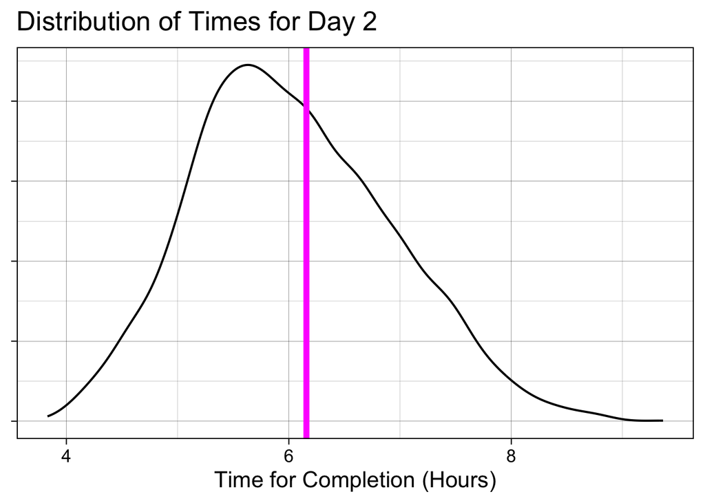

```r
library(tidyverse)

day2 <- read.csv("data/day2_full.csv")

pred_mod <- lm(value ~ boatType + temp + water + n_paddler, day2)
data <- data.frame(boatType = "Canoe", temp = 63,
                   water = 2.75, n_paddler = 2)

ggplot(data = day2, aes(x = value)) +
      geom_density() +
      geom_vline(xintercept = predict(pred_mod, data),
                 color = "magenta", linewidth = 2) +
      theme_linedraw(base_size = 16) +
      theme(axis.title.y = element_blank(),
            axis.text.y = element_blank()) +
      labs(x = "Time for Completion (Hours)",
           title = ("Distribution of Times for Day 2"))
```

The prediction is about 6.16 hours, which we can see is above the mode time for day 2. Now, using the Shiny App, we can compare these conditions with some that are similar in most ways, but not all. In 2011, the temperature was 63 degrees, but the water level was 7.28 ft. The image below shows a screenshot from the Shiny App with these conditions as input (*the water level is 7.25 instead of 7.28, but this difference is negligible).

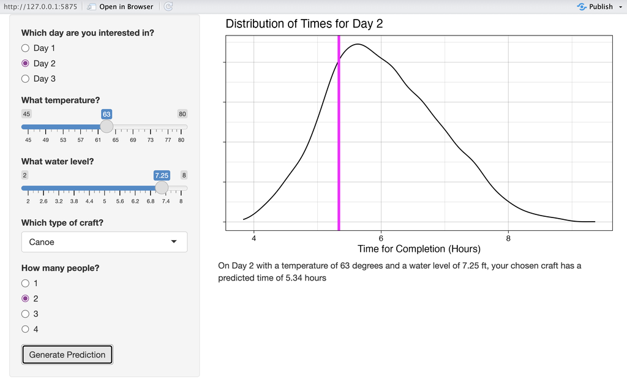

The time now is 5.34 hours. Compared with the first result, this time is much faster. Now, it lies below the mode time for day 2. This represents a use case for this model: before future races, competitors or race officials can input real water level and temperature data and receive time predictions. This is incredibly useful for teams who want to set goals, or officials who need to know when to be prepared for boats.

## Conclusion

This project was motivated by Ryan Matthews’ [similar work](https://www.ausablecanoemarathon.org/stats-and-history/estimated-winning-time/) for the AuSable River Marathon, however, the model resulting from this project is much less complex. Although, it is more transparent, which is a value I am committed to. Given more time, I would have loved to find a way to account for paddlers’ experience levels within the predictions; perhaps individuals who have completed the race many times before tend to be faster. I also would have been interested in expanding my weather data. Looking at precipitation, humidity, or cloud cover would have been interesting things to consider. Even within the data I had, it might have been interesting to explore non-linear relationships or interaction terms.